# problem1-Tushar

```python
import pandas as pd
import numpy as np
import seaborn as sns
import matplotlib.pyplot as plt
```

```python
df = pd.read_csv('athlete_events.csv')
df.head()
```

|  | ID | Name | Sex | Age | Height | Weight | Team | NOC | Games | Year | Season | City | Sport | Event | Medal |
| --- | --- | --- | --- | --- | --- | --- | --- | --- | --- | --- | --- | --- | --- | --- | --- |
| 0 | 1 | A Dijiang | M | 24.0 | 180.0 | 80.0 | China | CHN | 1992 Summer | 1992 | Summer | Barcelona | Basketball | Basketball Men's Basketball | NaN |
| 1 | 2 | A Lamusi | M | 23.0 | 170.0 | 60.0 | China | CHN | 2012 Summer | 2012 | Summer | London | Judo | Judo Men's Extra-Lightweight | NaN |
| 2 | 3 | Gunnar Nielsen Aaby | M | 24.0 | NaN | NaN | Denmark | DEN | 1920 Summer | 1920 | Summer | Antwerpen | Football | Football Men's Football | NaN |
| 3 | 4 | Edgar Lindenau Aabye | M | 34.0 | NaN | NaN | Denmark/Sweden | DEN | 1900 Summer | 1900 | Summer | Paris | Tug-Of-War | Tug-Of-War Men's Tug-Of-War | Gold |
| 4 | 5 | Christine Jacoba Aaftink | F | 21.0 | 185.0 | 82.0 | Netherlands | NED | 1988 Winter | 1988 | Winter | Calgary | Speed Skating | Speed Skating Women's 500 metres | NaN |

```python
df.shape
```

```
(271116, 15)
```

# 1.Handle null values in dataset and remove unwanted symbols if any

```python
df.isnull().sum()
```

```
ID             0
Name           0
Sex            0
Age         9474
Height     60171
Weight     62875
Team           0
NOC            0
Games          0
Year           0
Season         0
City           0
Sport          0
Event          0
Medal     231333
dtype: int64
```

#### There are null values only in Age, Height, weight and medal features.

### Age

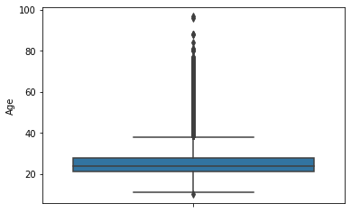

```python
sns.boxplot(y = df.Age)
```

There are many outliers in the age. So we cant consider the mean to fill the null values. We have to consider the madian instead.

```python
df['Age']= df['Age'].fillna(df['Age'].median())
```

### Height

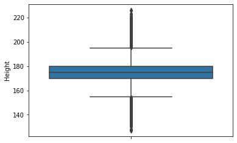

```python
sns.boxplot(y = df.Height)
```

```python
df['Height']= df['Height'].fillna(df['Height'].median())
```

### Weight

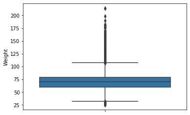

```python
sns.boxplot(y = df.Weight)
```

```python
df['Weight']= df['Weight'].fillna(df['Weight'].median())
```

### Medal

There are many records are missing in medal features. It simply means that those records are without any medal. They have not won any medal. So we can replace that with No_medal.

```python
df['Medal']= df['Medal'].fillna('No_medal')
```

# 2. What is the unique count of sports, events, and different city, and the team participated in the Olympics.

```python
print("Number of Unique sports were played in the olympic is",len(df.Sport.unique()))
```

```
Number of Unique sports were played in the olympic is 66
```

```python
print("Number of Unique events were there in the olympic is",len(df.Event.unique()))
```

```
Number of Unique events were there in the olympic is 765
```

```python
print("Number of Unique city were participated in the olympic is",len(df.City.unique()))
```

```
Number of Unique city were participated in the olympic is 42
```

```python
print("Number of Unique team were participated in the olympic is",len(df.Team.unique()))
```

```
Number of Unique team were participated in the olympic is 1184
```

# 3. What is the total count of players from the United States, China, Netherland, Spain, France, Italy?

```python
l = ['United States','China','Netherlands','Spain','France','Italy']
for team in l:
    print(f"Total number of players from {team} is",len(df[df.Team==team]['Name'].unique()))
```

```
Total number of players from United States is 9114
Total number of players from China is 2437
Total number of players from Netherlands is 2862
Total number of players from Spain is 2597
Total number of players from France is 5777
Total number of players from Italy is 4688
```

# 4. What is the average age of female and male players from the United States, China, Netherland, Spain, France, Italy?

```python
for team in l:
    print(f"The average age of female player from {team} is",df[df.Team==team].groupby('Sex', as_index=True).Age.mean()[0])
    print(f"The average age of male player from {team} is",df[df.Team==team].groupby('Sex', as_index=True).Age.mean()[1])
    print("----------------------------------------")
    print("\n")
```

```
The average age of female player from United States is 24.451378539493295
The average age of male player from United States is 26.535940379838127
----------------------------------------


The average age of female player from China is 22.323606434717547
The average age of male player from China is 23.68679409209383
----------------------------------------


The average age of female player from Netherlands is 24.113564668769715
The average age of male player from Netherlands is 27.76912997903564
----------------------------------------


The average age of female player from Spain is 23.22676056338028
The average age of male player from Spain is 25.942954784437433
----------------------------------------


The average age of female player from France is 24.164418519868757
The average age of male player from France is 27.060248783126013
----------------------------------------


The average age of female player from Italy is 23.526357827476037
The average age of male player from Italy is 26.387313047962866
----------------------------------------
```

# 5. What are the different kinds of sports in which players have participated in different cities of the United States.

```python
print("Different kinds of sports in which players have participated in different cities of the united states is", df[df.Team=="United States"]['Sport'].unique())
```

```
Different kinds of sports in which players have participated in different cities of the united states is ['Cross Country Skiing' 'Wrestling' 'Athletics' 'Figure Skating' 'Cycling'
 'Golf' 'Softball' 'Taekwondo' 'Rowing' 'Basketball'
 'Synchronized Swimming' 'Ice Hockey' 'Baseball' 'Handball'
 'Weightlifting' 'Fencing' 'Swimming' 'Shooting' 'Archery' 'Volleyball'
 'Art Competitions' 'Sailing' 'Alpine Skiing' 'Boxing' 'Football' 'Tennis'
 'Judo' 'Snowboarding' 'Nordic Combined' 'Trampolining' 'Biathlon'
 'Ski Jumping' 'Freestyle Skiing' 'Diving' 'Modern Pentathlon'
 'Equestrianism' 'Gymnastics' 'Polo' 'Short Track Speed Skating' 'Hockey'
 'Water Polo' 'Canoeing' 'Skeleton' 'Speed Skating' 'Badminton'
 'Rugby Sevens' 'Table Tennis' 'Curling' 'Triathlon' 'Luge'
 'Rhythmic Gymnastics' 'Tug-Of-War' 'Roque' 'Rugby' 'Jeu De Paume']
```

# 6. What are the names of players who have brought gold, silver and bronze medal?

```python
medal = ['Bronze', 'Silver', 'Gold']
for i in medal:
    print(f"The name of players who have brought {i} is", df[df.Medal==i]['Name'].unique())
    print("\n")
```

```
The name of players who have brought Bronze is ['Arvo Ossian Aaltonen' 'Juhamatti Tapio Aaltonen'
 'Paavo Johannes Aaltonen' ... 'Galina Ivanovna Zybina (-Fyodorova)'
 'Bogusaw Zych' 'Olesya Nikolayevna Zykina']


The name of players who have brought Silver is ['Kjetil Andr Aamodt' 'Alf Lied Aanning' 'Pepijn Aardewijn' ...
 'Krzysztof Zwoliski' 'Galina Ivanovna Zybina (-Fyodorova)'
 'Olesya Nikolayevna Zykina']


The name of players who have brought Gold is ['Edgar Lindenau Aabye' 'Paavo Johannes Aaltonen' 'Kjetil Andr Aamodt' ...
 'Ronald Ferdinand "Ron" Zwerver' 'Henk Jan Zwolle'
 'Galina Ivanovna Zybina (-Fyodorova)']
```

# 7.Which team has brought the most number of female and male players?

```python
l1 = df['Team'].unique()
no_of_male = []
for i in l1:
    no_of_male.append(len(df[df.Sex=='M'][df.Team==i]['Name'].unique()))
```

```python
for i in l1:
    if len(df[df.Sex=='M'][df.Team==i]['Name'].unique())==max(no_of_male):
        print("THe team who has brought max no of male player is", i)
```

```
THe team who has brought max no of male player is United States
```

```python
l1 = df['Team'].unique()
no_of_female = []
for i in l1:
    no_of_female.append(len(df[df.Sex=='F'][df.Team==i]['Name'].unique()))
for i in l1:
    if len(df[df.Sex=='F'][df.Team==i]['Name'].unique())==max(no_of_female):
        print("THe team who has brought max no of female player is", i)
```

```
THe team who has brought max no of female player is United States
```

# 8. Draw a suitable graph which depicts different events took place from 1900 to 2016.

```python
df1 = df[(df.Year >= 1900) & (df.Year<=2016)]
df1.head()
```

|  | ID | Name | Sex | Age | Height | Weight | Team | NOC | Games | Year | Season | City | Sport | Event | Medal |
| --- | --- | --- | --- | --- | --- | --- | --- | --- | --- | --- | --- | --- | --- | --- | --- |
| 0 | 1 | A Dijiang | M | 24.0 | 180.0 | 80.0 | China | CHN | 1992 Summer | 1992 | Summer | Barcelona | Basketball | Basketball Men's Basketball | No_medal |
| 1 | 2 | A Lamusi | M | 23.0 | 170.0 | 60.0 | China | CHN | 2012 Summer | 2012 | Summer | London | Judo | Judo Men's Extra-Lightweight | No_medal |
| 2 | 3 | Gunnar Nielsen Aaby | M | 24.0 | 175.0 | 70.0 | Denmark | DEN | 1920 Summer | 1920 | Summer | Antwerpen | Football | Football Men's Football | No_medal |
| 3 | 4 | Edgar Lindenau Aabye | M | 34.0 | 175.0 | 70.0 | Denmark/Sweden | DEN | 1900 Summer | 1900 | Summer | Paris | Tug-Of-War | Tug-Of-War Men's Tug-Of-War | Gold |
| 4 | 5 | Christine Jacoba Aaftink | F | 21.0 | 185.0 | 82.0 | Netherlands | NED | 1988 Winter | 1988 | Winter | Calgary | Speed Skating | Speed Skating Women's 500 metres | No_medal |

[figure not shown]

```python
#plt.figure(figsize=(25,50))
sns.catplot(x="Year", y="Event",data=df1)
```